# FASHION MNIST CLASSIFICATION PROJECT

# SINAN BILIR

## **Introduction**

The Fashion MNIST dataset, consisting of 70,000 grayscale images across 10 distinct clothing categories, was employed to evaluate the effectiveness of neural network architectures in image classification (Singh, 2020). The dataset is a well-established benchmark for machine learning and deep learning research, enabling comparisons across various model architectures and techniques.

Three models were implemented in this project:

1. **Sigmoid Activation Model:** A baseline model designed with Sigmoid activation functions in the hidden layers.
2. **ReLU Activation Model:** Enhanced to improve training efficiency by addressing vanishing gradient issues.
3. **Dropout Regularization Model:** Incorporated Dropout layers to mitigate overfitting and enhance generalization capabilities.

Each model was trained to classify images accurately, with performance evaluated using metrics like training loss, validation loss, and confusion matrices. This analysis highlighted the impact of activation functions and regularization on model performance.

The dataset was preprocessed by normalizing pixel values to [0, 1] and converting labels into a one-hot encoded format for compatibility with categorical cross-entropy loss. A grid of 25 sample images verified the integrity of the dataset.

Validation accuracy trends showed the ReLU model was the most accurate, followed by Dropout. Confusion matrices revealed class-level strengths, with the ReLU model excelling in identifying challenging categories and the Dropout model demonstrating better generalization.

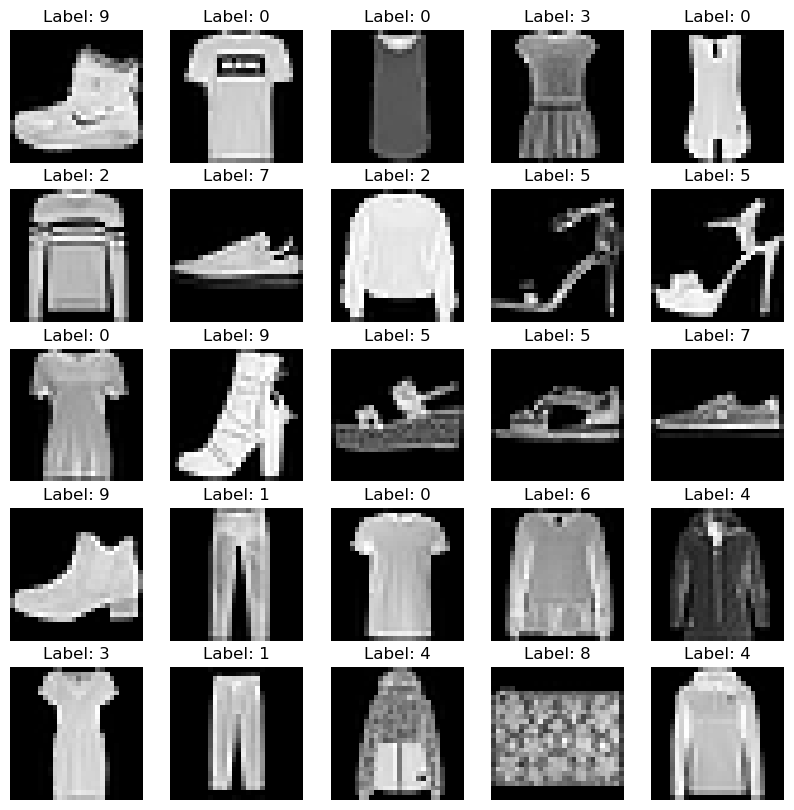

```python
# Import necessary libraries
import tensorflow as tf
from tensorflow.keras.datasets import fashion_mnist
from tensorflow.keras.models import Sequential
from tensorflow.keras.layers import Dense, Dropout, Flatten, Input
from tensorflow.keras.optimizers import SGD
from tensorflow.keras.utils import to_categorical
import matplotlib.pyplot as plt
import numpy as np
from sklearn.metrics import confusion_matrix, ConfusionMatrixDisplay

# Load dataset
(train_images, train_labels), (test_images, test_labels) = fashion_mnist.load_data()

# Normalize pixel values
train_images, test_images = train_images / 255.0, test_images / 255.0

# One-hot encode labels
train_labels_onehot = to_categorical(train_labels, 10)
test_labels_onehot = to_categorical(test_labels, 10)

# Visualize sample images
plt.figure(figsize=(10, 10))
for i in range(25):
    plt.subplot(5, 5, i + 1)
    plt.imshow(train_images[i], cmap='gray')
    plt.title(f"Label: {train_labels[i]}")
    plt.axis('off')
plt.show()
```

### **Figure 1** : Grid of 25 sample images with labels. Caption: "Sample Images from the Fashion MNIST Dataset."

## **2. Model Design and Training**

### **Sigmoid Activation Model**

The Sigmoid model, using two hidden layers with Sigmoid activation, was trained for 20 epochs. While functional, the model experienced slower convergence due to vanishing gradients.

```python
# Build Sigmoid model
model_sigmoid = Sequential([
    Input(shape=(28, 28)),
    Flatten(),
    Dense(512, activation='sigmoid'),
    Dense(256, activation='sigmoid'),
    Dense(10, activation='softmax')
])

# Compile and train the model
model_sigmoid.compile(optimizer=SGD(learning_rate=0.01), loss='categorical_crossentropy', metrics=['accuracy'])
history_sigmoid = model_sigmoid.fit(train_images, train_labels_onehot, validation_data=(test_images, test_labels_onehot), epochs=20, batch_size=500)

# Evaluate the model
test_loss_sigmoid, test_acc_sigmoid = model_sigmoid.evaluate(test_images, test_labels_onehot)
print(f"Sigmoid Test Accuracy: {test_acc_sigmoid:.4f}")
```

```
2024-11-25 17:25:37.269484: W external/local_tsl/tsl/framework/cpu_allocator_impl.cc:83] Allocation of 188160000 exceeds 10% of free system memory.
```

```
120/120 ━━━━━━━━━━━━━━━━━━━━ 2s 16ms/step - accuracy: 0.1526 - loss: 2.3766 - val_accuracy: 0.3078 - val_loss: 2.2532
120/120 ━━━━━━━━━━━━━━━━━━━━ 1s 11ms/step - accuracy: 0.4015 - loss: 2.2416 - val_accuracy: 0.4748 - val_loss: 2.2062
120/120 ━━━━━━━━━━━━━━━━━━━━ 1s 10ms/step - accuracy: 0.4823 - loss: 2.1934 - val_accuracy: 0.5103 - val_loss: 2.1555
120/120 ━━━━━━━━━━━━━━━━━━━━ 2s 13ms/step - accuracy: 0.5237 - loss: 2.1409 - val_accuracy: 0.4968 - val_loss: 2.0991
120/120 ━━━━━━━━━━━━━━━━━━━━ 3s 28ms/step - accuracy: 0.5474 - loss: 2.0833 - val_accuracy: 0.5331 - val_loss: 2.0352
120/120 ━━━━━━━━━━━━━━━━━━━━ 3s 11ms/step - accuracy: 0.5478 - loss: 2.0164 - val_accuracy: 0.5465 - val_loss: 1.9640
120/120 ━━━━━━━━━━━━━━━━━━━━ 1s 10ms/step - accuracy: 0.5497 - loss: 1.9440 - val_accuracy: 0.5559 - val_loss: 1.8859
120/120 ━━━━━━━━━━━━━━━━━━━━ 1s 11ms/step - accuracy: 0.5606 - loss: 1.8627 - val_accuracy: 0.5621 - val_loss: 1.8040
120/120 ━━━━━━━━━━━━━━━━━━━━ 1s 12ms/step - accuracy: 0.5785 - loss: 1.7829 - val_accuracy: 0.5701 - val_loss: 1.7225
120/120 ━━━━━━━━━━━━━━━━━━━━ 1s 11ms/step - accuracy: 0.5783 - loss: 1.7017 - val_accuracy: 0.5890 - val_loss: 1.6444
120/120 ━━━━━━━━━━━━━━━━━━━━ 1s 11ms/step - accuracy: 0.5982 - loss: 1.6226 - val_accuracy: 0.5998 - val_loss: 1.5720
120/120 ━━━━━━━━━━━━━━━━━━━━ 3s 11ms/step - accuracy: 0.6042 - loss: 1.5513 - val_accuracy: 0.6132 - val_loss: 1.5056
120/120 ━━━━━━━━━━━━━━━━━━━━ 7s 47ms/step - accuracy: 0.6159 - loss: 1.4875 - val_accuracy: 0.6286 - val_loss: 1.4447
120/120 ━━━━━━━━━━━━━━━━━━━━ 2s 19ms/step - accuracy: 0.6285 - loss: 1.4265 - val_accuracy: 0.6403 - val_loss: 1.3904
120/120 ━━━━━━━━━━━━━━━━━━━━ 2s 19ms/step - accuracy: 0.6426 - loss: 1.3748 - val_accuracy: 0.6474 - val_loss: 1.3408
120/120 ━━━━━━━━━━━━━━━━━━━━ 2s 10ms/step - accuracy: 0.6529 - loss: 1.3253 - val_accuracy: 0.6595 - val_loss: 1.2961
120/120 ━━━━━━━━━━━━━━━━━━━━ 1s 11ms/step - accuracy: 0.6596 - loss: 1.2804 - val_accuracy: 0.6677 - val_loss: 1.2559
120/120 ━━━━━━━━━━━━━━━━━━━━ 2s 13ms/step - accuracy: 0.6650 - loss: 1.2427 - val_accuracy: 0.6668 - val_loss: 1.2193
120/120 ━━━━━━━━━━━━━━━━━━━━ 3s 13ms/step - accuracy: 0.6712 - loss: 1.2064 - val_accuracy: 0.6715 - val_loss: 1.1860
120/120 ━━━━━━━━━━━━━━━━━━━━ 3s 15ms/step - accuracy: 0.6776 - loss: 1.1735 - val_accuracy: 0.6783 - val_loss: 1.1556
313/313 ━━━━━━━━━━━━━━━━━━━━ 1s 2ms/step - accuracy: 0.6725 - loss: 1.1579
Sigmoid Test Accuracy: 0.6783
```

### **Figure 2**: Accuracy and loss plots for the Sigmoid model.

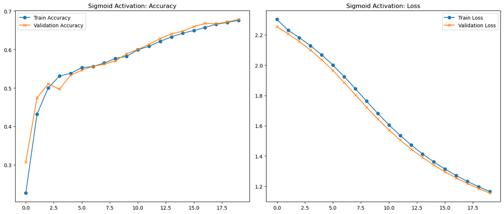

```python
# Plot accuracy and loss for Sigmoid model
plt.figure(figsize=(14, 6))
plt.subplot(1, 2, 1)
plt.plot(history_sigmoid.history['accuracy'], label='Train Accuracy', marker='o')
plt.plot(history_sigmoid.history['val_accuracy'], label='Validation Accuracy', marker='x')
plt.title('Sigmoid Activation: Accuracy')
plt.legend()

plt.subplot(1, 2, 2)
plt.plot(history_sigmoid.history['loss'], label='Train Loss', marker='o')
plt.plot(history_sigmoid.history['val_loss'], label='Validation Loss', marker='x')
plt.title('Sigmoid Activation: Loss')
plt.legend()

plt.tight_layout()
plt.show()
```

## **ReLU Activation Model**

Replacing Sigmoid activation with ReLU allowed for faster convergence and better accuracy (Rashid, 2023). This model was trained for 15 epochs.

```python
# Build ReLU model
model_relu = Sequential([
    Input(shape=(28, 28)),
    Flatten(),
    Dense(512, activation='relu'),
    Dense(256, activation='relu'),
    Dense(10, activation='softmax')
])

# Compile and train the model
model_relu.compile(optimizer=SGD(learning_rate=0.01), loss='categorical_crossentropy', metrics=['accuracy'])
history_relu = model_relu.fit(train_images, train_labels_onehot, validation_data=(test_images, test_labels_onehot), epochs=15, batch_size=500)

# Evaluate the model
test_loss_relu, test_acc_relu = model_relu.evaluate(test_images, test_labels_onehot)
print(f"ReLU Test Accuracy: {test_acc_relu:.4f}")
```

```
2024-11-25 17:27:09.744085: W external/local_tsl/tsl/framework/cpu_allocator_impl.cc:83] Allocation of 188160000 exceeds 10% of free system memory.
```

```
120/120 ━━━━━━━━━━━━━━━━━━━━ 2s 13ms/step - accuracy: 0.4597 - loss: 1.8591 - val_accuracy: 0.6696 - val_loss: 1.0852
120/120 ━━━━━━━━━━━━━━━━━━━━ 1s 10ms/step - accuracy: 0.6944 - loss: 0.9954 - val_accuracy: 0.7270 - val_loss: 0.8407
120/120 ━━━━━━━━━━━━━━━━━━━━ 1s 11ms/step - accuracy: 0.7472 - loss: 0.7996 - val_accuracy: 0.7578 - val_loss: 0.7419
120/120 ━━━━━━━━━━━━━━━━━━━━ 2s 10ms/step - accuracy: 0.7730 - loss: 0.7147 - val_accuracy: 0.7765 - val_loss: 0.6831
120/120 ━━━━━━━━━━━━━━━━━━━━ 2s 15ms/step - accuracy: 0.7926 - loss: 0.6529 - val_accuracy: 0.7858 - val_loss: 0.6424
120/120 ━━━━━━━━━━━━━━━━━━━━ 2s 13ms/step - accuracy: 0.8007 - loss: 0.6186 - val_accuracy: 0.7954 - val_loss: 0.6125
120/120 ━━━━━━━━━━━━━━━━━━━━ 1s 11ms/step - accuracy: 0.8139 - loss: 0.5811 - val_accuracy: 0.8022 - val_loss: 0.5885
120/120 ━━━━━━━━━━━━━━━━━━━━ 1s 10ms/step - accuracy: 0.8167 - loss: 0.5604 - val_accuracy: 0.8093 - val_loss: 0.5701
120/120 ━━━━━━━━━━━━━━━━━━━━ 1s 10ms/step - accuracy: 0.8214 - loss: 0.5430 - val_accuracy: 0.8129 - val_loss: 0.5546
120/120 ━━━━━━━━━━━━━━━━━━━━ 2s 15ms/step - accuracy: 0.8263 - loss: 0.5279 - val_accuracy: 0.8157 - val_loss: 0.5432
120/120 ━━━━━━━━━━━━━━━━━━━━ 2s 16ms/step - accuracy: 0.8277 - loss: 0.5170 - val_accuracy: 0.8199 - val_loss: 0.5322
120/120 ━━━━━━━━━━━━━━━━━━━━ 1s 11ms/step - accuracy: 0.8299 - loss: 0.5078 - val_accuracy: 0.8211 - val_loss: 0.5229
120/120 ━━━━━━━━━━━━━━━━━━━━ 1s 11ms/step - accuracy: 0.8327 - loss: 0.4989 - val_accuracy: 0.8237 - val_loss: 0.5152
120/120 ━━━━━━━━━━━━━━━━━━━━ 2s 14ms/step - accuracy: 0.8366 - loss: 0.4887 - val_accuracy: 0.8268 - val_loss: 0.5075
120/120 ━━━━━━━━━━━━━━━━━━━━ 3s 14ms/step - accuracy: 0.8362 - loss: 0.4820 - val_accuracy: 0.8278 - val_loss: 0.5003
313/313 ━━━━━━━━━━━━━━━━━━━━ 1s 2ms/step - accuracy: 0.8310 - loss: 0.4926
ReLU Test Accuracy: 0.8278
```

### **Figure 3**: Accuracy and loss plots for the ReLU model.

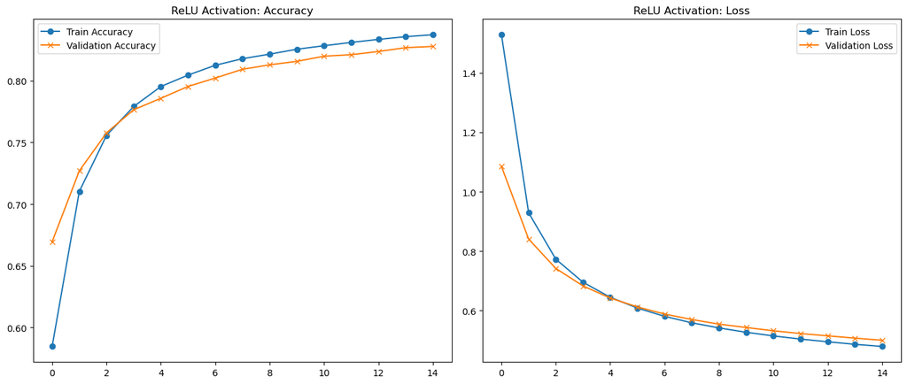

```python
# Plot accuracy and loss for ReLU model
plt.figure(figsize=(14, 6))

# Accuracy plot
plt.subplot(1, 2, 1)
plt.plot(history_relu.history['accuracy'], label='Train Accuracy', marker='o')
plt.plot(history_relu.history['val_accuracy'], label='Validation Accuracy', marker='x')
plt.title('ReLU Activation: Accuracy')
plt.legend()

# Loss plot
plt.subplot(1, 2, 2)
plt.plot(history_relu.history['loss'], label='Train Loss', marker='o')
plt.plot(history_relu.history['val_loss'], label='Validation Loss', marker='x')
plt.title('ReLU Activation: Loss')
plt.legend()

plt.tight_layout()
plt.show()
```

## **Dropout Regularization Model**

Dropout layers were added to reduce overfitting, improving generalization (Brownlee, 2018). This model was also trained for 15 epochs.

```python
# Build Dropout model
model_dropout = Sequential([
    Input(shape=(28, 28)),
    Flatten(),
    Dense(512, activation='relu'),
    Dropout(0.5),
    Dense(256, activation='relu'),
    Dropout(0.5),
    Dense(10, activation='softmax')
])

# Compile and train the model
model_dropout.compile(optimizer=SGD(learning_rate=0.01), loss='categorical_crossentropy', metrics=['accuracy'])
history_dropout = model_dropout.fit(train_images, train_labels_onehot, validation_data=(test_images, test_labels_onehot), epochs=15, batch_size=500)

# Evaluate the model
test_loss_dropout, test_acc_dropout = model_dropout.evaluate(test_images, test_labels_onehot)
print(f"Dropout Test Accuracy: {test_acc_dropout:.4f}")
```

```
2024-11-25 17:27:59.734417: W external/local_tsl/tsl/framework/cpu_allocator_impl.cc:83] Allocation of 188160000 exceeds 10% of free system memory.
```

```
120/120 ━━━━━━━━━━━━━━━━━━━━ 6s 48ms/step - accuracy: 0.2388 - loss: 2.1236 - val_accuracy: 0.6341 - val_loss: 1.2913
120/120 ━━━━━━━━━━━━━━━━━━━━ 8s 26ms/step - accuracy: 0.5193 - loss: 1.4106 - val_accuracy: 0.6593 - val_loss: 0.9905
120/120 ━━━━━━━━━━━━━━━━━━━━ 4s 17ms/step - accuracy: 0.5924 - loss: 1.1548 - val_accuracy: 0.6871 - val_loss: 0.8688
120/120 ━━━━━━━━━━━━━━━━━━━━ 2s 14ms/step - accuracy: 0.6321 - loss: 1.0297 - val_accuracy: 0.7078 - val_loss: 0.8047
120/120 ━━━━━━━━━━━━━━━━━━━━ 2s 13ms/step - accuracy: 0.6626 - loss: 0.9484 - val_accuracy: 0.7216 - val_loss: 0.7620
120/120 ━━━━━━━━━━━━━━━━━━━━ 3s 12ms/step - accuracy: 0.6809 - loss: 0.8985 - val_accuracy: 0.7334 - val_loss: 0.7303
120/120 ━━━━━━━━━━━━━━━━━━━━ 2s 13ms/step - accuracy: 0.6962 - loss: 0.8541 - val_accuracy: 0.7465 - val_loss: 0.7023
120/120 ━━━━━━━━━━━━━━━━━━━━ 2s 16ms/step - accuracy: 0.7072 - loss: 0.8264 - val_accuracy: 0.7568 - val_loss: 0.6796
120/120 ━━━━━━━━━━━━━━━━━━━━ 2s 16ms/step - accuracy: 0.7200 - loss: 0.7944 - val_accuracy: 0.7625 - val_loss: 0.6617
120/120 ━━━━━━━━━━━━━━━━━━━━ 3s 21ms/step - accuracy: 0.7285 - loss: 0.7733 - val_accuracy: 0.7678 - val_loss: 0.6444
120/120 ━━━━━━━━━━━━━━━━━━━━ 2s 15ms/step - accuracy: 0.7358 - loss: 0.7533 - val_accuracy: 0.7719 - val_loss: 0.6308
120/120 ━━━━━━━━━━━━━━━━━━━━ 2s 12ms/step - accuracy: 0.7400 - loss: 0.7365 - val_accuracy: 0.7795 - val_loss: 0.6157
120/120 ━━━━━━━━━━━━━━━━━━━━ 2s 17ms/step - accuracy: 0.7534 - loss: 0.7068 - val_accuracy: 0.7846 - val_loss: 0.6058
120/120 ━━━━━━━━━━━━━━━━━━━━ 2s 13ms/step - accuracy: 0.7582 - loss: 0.6943 - val_accuracy: 0.7905 - val_loss: 0.5937
120/120 ━━━━━━━━━━━━━━━━━━━━ 2s 13ms/step - accuracy: 0.7617 - loss: 0.6817 - val_accuracy: 0.7933 - val_loss: 0.5851
313/313 ━━━━━━━━━━━━━━━━━━━━ 1s 2ms/step - accuracy: 0.7992 - loss: 0.5782
Dropout Test Accuracy: 0.7933
```

### **Figure 4**: Accuracy and loss plots for the Dropout model.

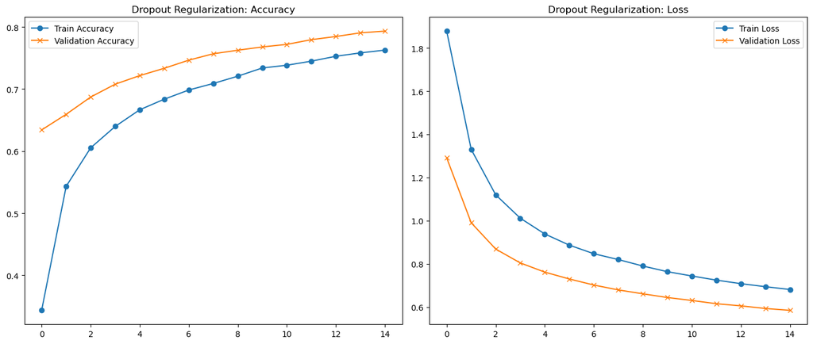

```python
# Plot accuracy and loss for Dropout model
plt.figure(figsize=(14, 6))

# Accuracy plot
plt.subplot(1, 2, 1)
plt.plot(history_dropout.history['accuracy'], label='Train Accuracy', marker='o')
plt.plot(history_dropout.history['val_accuracy'], label='Validation Accuracy', marker='x')
plt.title('Dropout Regularization: Accuracy')
plt.legend()

# Loss plot
plt.subplot(1, 2, 2)
plt.plot(history_dropout.history['loss'], label='Train Loss', marker='o')
plt.plot(history_dropout.history['val_loss'], label='Validation Loss', marker='x')
plt.title('Dropout Regularization: Loss')
plt.legend()

plt.tight_layout()
plt.show()
```

## **3. Results and Comparisons**

### **Validation Accuracy Comparison**

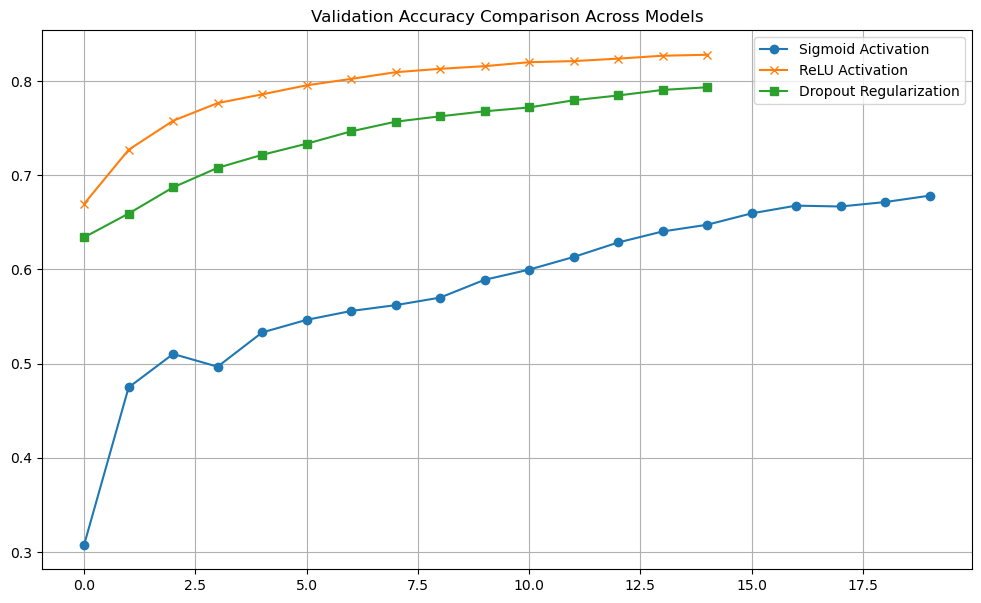

```python
# Plot validation accuracy for all models
plt.figure(figsize=(12, 7))
plt.plot(history_sigmoid.history['val_accuracy'], label='Sigmoid Activation', marker='o')
plt.plot(history_relu.history['val_accuracy'], label='ReLU Activation', marker='x')
plt.plot(history_dropout.history['val_accuracy'], label='Dropout Regularization', marker='s')
plt.title('Validation Accuracy Comparison Across Models')
plt.legend()
plt.grid()
plt.show()
```

## **Confusion Matrices**

The confusion matrices provided insight into class-level performance for each model.

1. **Sigmoid Model** **Figure 6**: Confusion Matrix for Sigmoid Model.
2. **ReLU Model** **Figure 7**: Confusion Matrix for ReLU Model.
3. **Dropout Model** **Figure 8**: Confusion Matrix for Dropout Model.

```
313/313 ━━━━━━━━━━━━━━━━━━━━ 1s 2ms/step
```

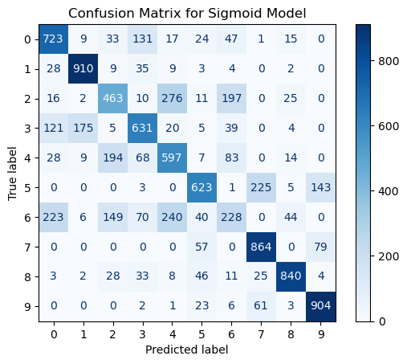

```python
# Confusion Matrix for Sigmoid Model
predictions_sigmoid = model_sigmoid.predict(test_images)
predicted_labels_sigmoid = np.argmax(predictions_sigmoid, axis=1)

cm_sigmoid = confusion_matrix(test_labels, predicted_labels_sigmoid)
disp_sigmoid = ConfusionMatrixDisplay(confusion_matrix=cm_sigmoid, display_labels=range(10))
disp_sigmoid.plot(cmap='Blues')
plt.title("Confusion Matrix for Sigmoid Model")
plt.show()
```

```
313/313 ━━━━━━━━━━━━━━━━━━━━ 2s 5ms/step
```

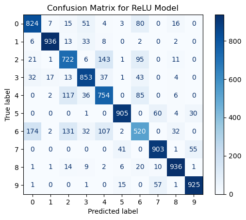

```python
# Confusion Matrix for ReLU Model
predictions_relu = model_relu.predict(test_images)
predicted_labels_relu = np.argmax(predictions_relu, axis=1)

cm_relu = confusion_matrix(test_labels, predicted_labels_relu)
disp_relu = ConfusionMatrixDisplay(confusion_matrix=cm_relu, display_labels=range(10))
disp_relu.plot(cmap='Blues')
plt.title("Confusion Matrix for ReLU Model")
plt.show()
```

```
313/313 ━━━━━━━━━━━━━━━━━━━━ 1s 2ms/step
```

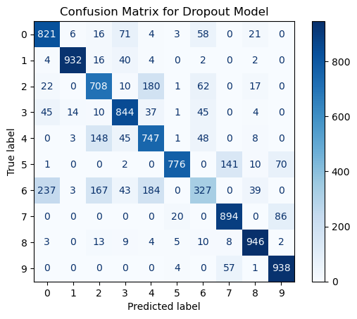

```python
# Confusion Matrix for Dropout Model
predictions_dropout = model_dropout.predict(test_images)
predicted_labels_dropout = np.argmax(predictions_dropout, axis=1)

cm_dropout = confusion_matrix(test_labels, predicted_labels_dropout)
disp_dropout = ConfusionMatrixDisplay(confusion_matrix=cm_dropout, display_labels=range(10))
disp_dropout.plot(cmap='Blues')
plt.title("Confusion Matrix for Dropout Model")
plt.show()
```

## **4. Summary Report**

```python
# Generate a summary report
report = f"""
=======================================
Fashion MNIST Classification Report
=======================================

Model Performance:
-------------------
1. Sigmoid Activation: {test_acc_sigmoid:.4f}
2. ReLU Activation: {test_acc_relu:.4f}
3. Dropout Regularization: {test_acc_dropout:.4f}

Observations:
-------------
- ReLU Activation significantly improves performance.
- Dropout ensures better generalization.

Conclusion:
-----------
Dropout Regularization is the optimal choice.
"""
print(report)
```

[output not shown]

## **Bibliography**

- **Rashid, M.** (2023) 'Activation Functions in Neural Networks: A Comprehensive Overview', *International Journal of Research in Computer Applications and Information Technology*, 7(2). Available at: https://ijrcait.com/index.php/home/article/view/IJRCAIT_07_02_016 (Accessed: 25 November 2024).
- **Brownlee, J.** (2018) 'A Gentle Introduction to Activation Regularization in Deep Learning', *Machine Learning Mastery*. Available at: https://machinelearningmastery.com/activation-regularization-for-reducing-generalization-error-in-deep-learning-neural-networks/ (Accessed: 25 November 2024).
- **Singh, S.S.** (2020) 'Fashion MNIST Classification using Neural Network', *GitHub Repository*. Available at: https://github.com/sssingh/fashion-mnist-classification (Accessed: 25 November 2024).
- **Brownlee, J.** (2019) 'Deep Learning CNN for Fashion-MNIST Clothing Classification', *Machine Learning Mastery*. Available at: https://machinelearningmastery.com/how-to-develop-a-cnn-from-scratch-for-fashion-mnist-clothing-classification/ (Accessed: 25 November 2024).
- **Raschka, S.** (2021) 'Lecture 10: Regularization Methods for Neural Networks', *Sebastian Raschka's Lecture Notes*. Available at: https://sebastianraschka.com/pdf/lecture-notes/stat453ss21/L10_regularization__slides.pdf (Accessed: 25 November 2024).